# CAPSTONE PROJECT 2023-2024

### Financial Graph Mining For Customers & Supply Chains Assessment

In order to improve the Bank’s CIB activities, a special attention is given to its clients transactions. Mapping out the supply chain of corporate customers is a strategic move that can enhance the bank’s risk management, client relationship and competitiveness in the market.

```python
import pandas as pd
import matplotlib.pyplot as plt
import seaborn as sns
from sklearn.preprocessing import LabelEncoder
import networkx as nx
import torch
from torch_geometric.data import Data
from torch_geometric.utils import from_networkx
import numpy as np
import plotly.graph_objects as go
import networkx as nx
from sklearn.preprocessing import StandardScaler
from sklearn.ensemble import RandomForestRegressor
from sklearn.model_selection import GridSearchCV
from sklearn.metrics import mean_squared_error, r2_score
from torch_geometric.nn import GCNConv
import torch.nn.functional as F
from torch_geometric.nn import BatchNorm
from torch.nn import Linear
import warnings
warnings.filterwarnings('ignore')
```

# PART 1: EXPLORATORY DATA ANALYSIS

### 1.1 Importing datasets and treatment of variables

```python
static_data = pd.read_csv('/home/jovyan/hfactory_magic_folders/financial_graph_mining_for_customers___supply_chains_assessment/static_data_all_x.csv',sep=';')
transactions_data = pd.read_csv('/home/jovyan/hfactory_magic_folders/financial_graph_mining_for_customers___supply_chains_assessment/transactions_x.csv',sep=';')
```

```python
def convert_probability(value):
    if '+' in str(value):
        return float(value.replace('+', '')) + 0.25
    elif '-' in str(value):
        return float(value.replace('-', '')) - 0.25
    else:
        return float(value)
def from_pred_to_normal(number):

    if 0 <= number <= 13:
        if number == 13:
            return "-13"
        else:
            base = int(number)
            if number - base < 0.1:
                return f"{base}"
            else:
                if number - base < 0.4:
                    return f"{base}+"
                else:
                    return f"-{base+1}"

static_data['T_LOCAL_TX_PD'] = static_data['T_LOCAL_TX_PD'].apply(convert_probability)
```

```python
test_data_=pd.read_csv('/home/jovyan/hfactory_magic_folders/financial_graph_mining_for_customers___supply_chains_assessment/static_data_x_PD.csv',sep=';')

## filtre solon T_LOCAL_MT_ACTIF_SOCIAL=NAN et QUARTER="q4"
test_data = test_data_.loc[(pd.isna(test_data_['T_LOCAL_MT_ACTIF_SOCIAL'])) & (test_data_['QUARTER'] == "q4")]
test_data_ = test_data_.loc[(pd.isna(test_data_['T_LOCAL_MT_ACTIF_SOCIAL'])) & (test_data_['QUARTER'] == "q4")]
test_data['T_LOCAL_TX_PD'] = test_data['T_LOCAL_TX_PD'].apply(convert_probability)
```

TRAITEMENT df,df_train ET df_test

```python
df=static_data
df_merged = pd.merge(test_data, df[['ID', 'T_LOCAL_MT_ACTIF_SOCIAL']], on='ID', how='left', suffixes=('', '_from_static_data'))
df_merged=df_merged.drop_duplicates()
df_merged.drop(columns=['T_LOCAL_MT_ACTIF_SOCIAL'], inplace=True)
df_merged.rename(columns={'T_LOCAL_MT_ACTIF_SOCIAL_from_static_data': 'T_LOCAL_MT_ACTIF_SOCIAL'}, inplace=True)
df_test=df_merged
df_test
```

|  | ID | REGION | ESG_SCORE | CATEGORY | T_LOCAL_TX_PD | QUARTER | T_LOCAL_MT_ACTIF_SOCIAL |
| --- | --- | --- | --- | --- | --- | --- | --- |
| 0 | 704576 | APAC | 3 | tier_2 | 3.75 | q4 | 3671 |
| 4 | 856665 | APAC | 3 | tier_2 | 5.75 | q4 | 1824 |
| 8 | 825899 | APAC | 4 | tier_2 | 6.00 | q4 | 1097 |
| 12 | 938287 | APAC | 5 | tier_2 | 7.25 | q4 | 2045 |
| 16 | 656517 | APAC | 5 | tier_2 | 4.75 | q4 | 1550 |
| ... | ... | ... | ... | ... | ... | ... | ... |
| 404 | 162521 | APAC | 3 | dealer | 5.75 | q4 | 49830 |
| 408 | 654792 | NAFTA | 5 | dealer | 5.00 | q4 | 52916 |
| 412 | 623606 | EMEA | 3 | dealer | 7.25 | q4 | 9001 |
| 416 | 985974 | NAFTA | 4 | dealer | 7.00 | q4 | 2813 |
| 420 | 850157 | APAC | 4 | dealer | 2.75 | q4 | 52069 |

106 rows × 7 columns

```python
df_train = pd.merge(df, df_test[['ID', 'QUARTER']], on=['ID', 'QUARTER'], how='left', indicator=True)
df_train = df_train[df_train['_merge'] == 'left_only']
df_train.drop(columns=['_merge'], inplace=True)
df_train
```

|  | ID | REGION | ESG_SCORE | CATEGORY | T_LOCAL_MT_ACTIF_SOCIAL | T_LOCAL_TX_PD | QUARTER |
| --- | --- | --- | --- | --- | --- | --- | --- |
| 0 | 185303 | LATAM | 4 | tier_2 | 34208 | 6.00 | q1 |
| 1 | 900683 | APAC | 5 | tier_2 | 1643 | 2.75 | q1 |
| 2 | 373869 | APAC | 4 | tier_2 | 4706 | 5.25 | q1 |
| 3 | 137542 | APAC | 4 | tier_2 | 2567 | 6.75 | q1 |
| 4 | 992171 | APAC | 3 | tier_2 | 1478 | 6.25 | q1 |
| ... | ... | ... | ... | ... | ... | ... | ... |
| 4511 | 200166 | APAC | 4 | dealer | 7517 | 6.75 | q4 |
| 4512 | 814235 | APAC | 3 | dealer | 7849 | 12.00 | q4 |
| 4513 | 162972 | NAFTA | 3 | dealer | 1172 | 5.75 | q4 |
| 4514 | 605883 | APAC | 2 | dealer | 59150 | 4.25 | q4 |
| 4515 | 804856 | NAFTA | 4 | dealer | 34876 | 7.25 | q4 |

4410 rows × 7 columns

```python
def onehotencoding(df,columns=None):
    # One-hot encode 'CATEGORY','REGION' and 'QUARTER'
    category_one_hot = pd.get_dummies(df['CATEGORY'], prefix='Cat')
    region_one_hot = pd.get_dummies(df['REGION'], prefix='Reg')
    quarter_one_hot=pd.get_dummies(df['QUARTER'])

    df = pd.concat([df, category_one_hot, region_one_hot,quarter_one_hot], axis=1)

    df.drop(['CATEGORY', 'REGION','QUARTER'], axis=1, inplace=True)
    df_converted = df.copy()
    if columns is None:
        columns = df_converted.columns
    for col in columns:
        if df_converted[col].dtype == bool:
            df_converted[col] = df_converted[col].astype(int)
    return df_converted
df_test_encoded=onehotencoding(df_test)
df_train_encoded=onehotencoding(df_train)
df_test_encoded = df_test_encoded.reindex(columns=df_train_encoded.columns, fill_value=0)
```

### 1.2 Basics analysis on features (we will use static data and transactions data)

In this part we will do some analysis on the companies only and make analysis based on quarter.

```python
static_data_unique=static_data.drop_duplicates(subset='ID') # To delete duplicates companies based on ID
print(static_data_unique.describe())
```

```
                  ID    ESG_SCORE  T_LOCAL_MT_ACTIF_SOCIAL  T_LOCAL_TX_PD
count    1129.000000  1129.000000             1.129000e+03    1129.000000
mean   553418.557130     3.875996             4.766139e+05       5.580381
std    264639.207543     0.945613             1.527971e+06       1.899869
min    100024.000000     1.000000             1.000000e+03       1.000000
25%    319301.000000     3.000000             2.179000e+03       4.250000
50%    558065.000000     4.000000             6.107000e+03       5.750000
75%    785114.000000     5.000000             4.449300e+04       6.750000
max    999092.000000     5.000000             7.973077e+06      12.000000
```

In total we have 1129 companies in our dataset. Default probability accross them is around 5.6 (from 0 to 13).

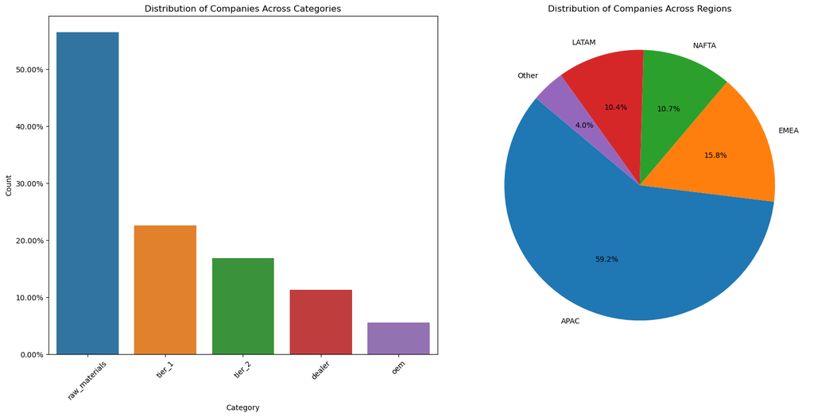

```python
categories_counts = static_data_unique['CATEGORY'].value_counts()
region_counts = static_data_unique['REGION'].value_counts()
total_categories = categories_counts.sum()
percentages_categories = 100 * categories_counts / total_categories

fig, (ax1, ax2) = plt.subplots(1, 2, figsize=(16, 8))

# Catégories
sns.barplot(x=categories_counts.index, y=categories_counts.values, ax=ax1)
ax1.set_title('Distribution of Companies Across Categories')
ax1.set_xlabel('Category')
ax1.set_ylabel('Count')
ax1.tick_params(axis='x', rotation=45)

# Ajout des étiquettes de pourcentage sur l'axe des y pour le graphique des catégories
ax1.set_yticklabels([f'{p:.2f}%' for p in np.linspace(0, 60, len(ax1.get_yticks()))])

# Régions
ax2.pie(region_counts, labels=region_counts.index, autopct='%1.1f%%', startangle=140)
ax2.set_title('Distribution of Companies Across Regions')

plt.tight_layout()
plt.show()
```

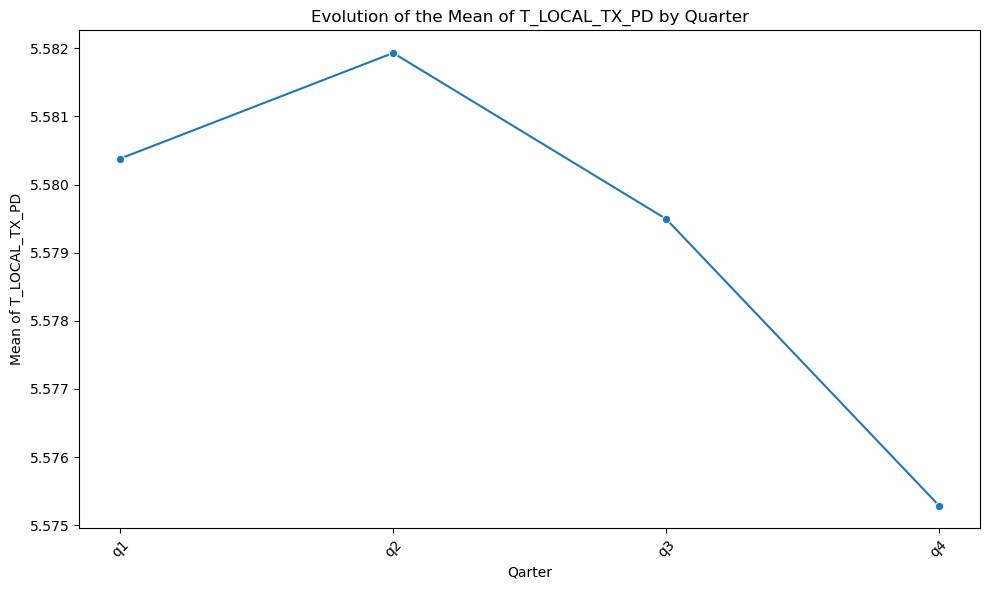

```python
mean_by_quarter = static_data.groupby('QUARTER')['T_LOCAL_TX_PD'].mean().reset_index()

plt.figure(figsize=(10, 6))
sns.lineplot(x='QUARTER', y='T_LOCAL_TX_PD', data=mean_by_quarter, marker='o')
plt.title('Evolution of the Mean of T_LOCAL_TX_PD by Quarter')
plt.xlabel('Qarter')
plt.ylabel('Mean of T_LOCAL_TX_PD')
plt.xticks(rotation=45)
plt.tight_layout()
plt.show()
```

Our target variable mean was quit high according to the other quarter in Q2. This mean was lesser in Q4.

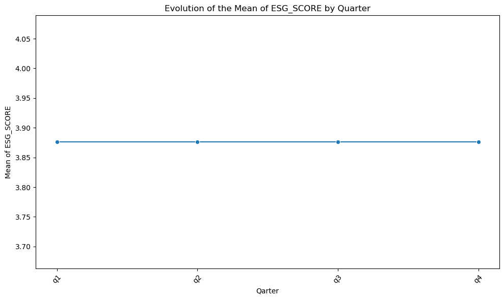

```python
mean_by_quarter_ = static_data.groupby('QUARTER')['ESG_SCORE'].mean().reset_index()

plt.figure(figsize=(10, 6))
sns.lineplot(x='QUARTER', y='ESG_SCORE', data=mean_by_quarter_, marker='o')
plt.title('Evolution of the Mean of ESG_SCORE by Quarter')
plt.xlabel('Qarter')
plt.ylabel('Mean of ESG_SCORE')
plt.xticks(rotation=45)
plt.tight_layout()
plt.show()
```

During all quarters the mean of the ESG score stayed at the same level which is around 3.87.

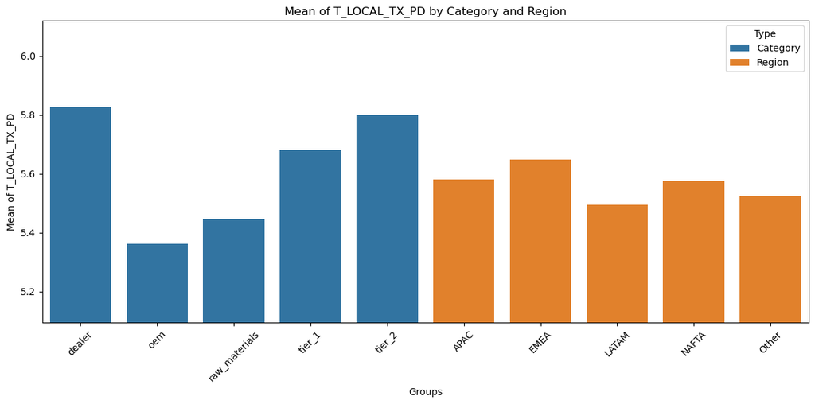

```python
mean_by_cat = static_data.groupby('CATEGORY')['T_LOCAL_TX_PD'].mean().reset_index()
mean_by_reg = static_data.groupby('REGION')['T_LOCAL_TX_PD'].mean().reset_index()

mean_by_cat['Type'] = 'Category'
mean_by_reg['Type'] = 'Region'
mean_by_cat.rename(columns={'CATEGORY': 'Group'}, inplace=True)
mean_by_reg.rename(columns={'REGION': 'Group'}, inplace=True)

combined_data = pd.concat([mean_by_cat, mean_by_reg])

plt.figure(figsize=(12, 6))
sns.barplot(x='Group', y='T_LOCAL_TX_PD', hue='Type', data=combined_data, dodge=False)
plt.title('Mean of T_LOCAL_TX_PD by Category and Region')
plt.xlabel('Groups')
plt.ylabel('Mean of T_LOCAL_TX_PD')
plt.xticks(rotation=45)
min_val = combined_data['T_LOCAL_TX_PD'].min() * 0.95
max_val = combined_data['T_LOCAL_TX_PD'].max() * 1.05
plt.ylim(min_val, max_val)
plt.tight_layout()
plt.show()
```

Companies in dealers category had a higher PD mean than other categories. The following category is company in tier2 and tier1. We also notice that companies in the region EMEA have the biggest PD mean accross this period. The region and category can be a little bit relevant to help predicting PD even if their contributions can be be small.

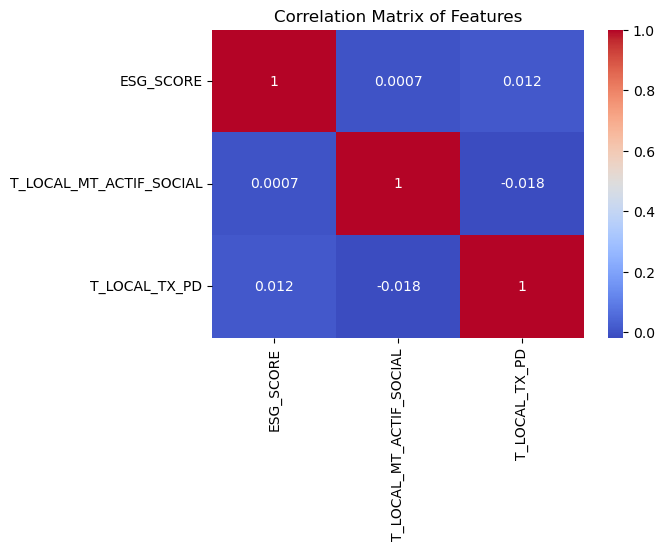

```python
plt.figure(figsize=(6, 4))
sns.heatmap(static_data[['ESG_SCORE','T_LOCAL_MT_ACTIF_SOCIAL','T_LOCAL_TX_PD']].corr(), annot=True, cmap='coolwarm')
plt.title('Correlation Matrix of Features')
plt.show()
```

```python
G_train = nx.DiGraph()

for _, row in df_train_encoded.iterrows():
    node_features = row.drop(['ID', 'T_LOCAL_TX_PD']).to_dict()
    G_train.add_node(row['ID'], **node_features, t_local_tx_pd=row['T_LOCAL_TX_PD'])


for _, row in transactions_data.iterrows():
    if row['ID'] in G_train and row['COUNTERPARTY'] in G_train:
        G_train.add_edge(row['ID'], row['COUNTERPARTY'], date=row['DATE'], tx_amount=row['TX_AMOUNT'])



print(f"Train Graph has {len(G_train.nodes)} nodes and {len(G_train.edges)} edges.")
```

```
Train Graph has 1129 nodes and 3297 edges.
```

```python
G_test = nx.DiGraph()

for _, row in df_test_encoded.iterrows():
    node_features = row.drop(['ID', 'T_LOCAL_TX_PD']).to_dict()
    G_test.add_node(row['ID'], **node_features, t_local_tx_pd=row['T_LOCAL_TX_PD'])


for _, row in transactions_data.iterrows():
    if row['ID'] in G_test and row['COUNTERPARTY'] in G_test:
        G_test.add_edge(row['ID'], row['COUNTERPARTY'], date=row['DATE'], tx_amount=row['TX_AMOUNT'])



print(f"Test Graph has {len(G_test.nodes)} nodes and {len(G_test.edges)} edges.")
```

```
Test Graph has 106 nodes and 49 edges.
```

```python
def plot_neighborhood(depth,G=G_train, node_id=373869):

    neighbors = nx.single_source_shortest_path_length(G, node_id, cutoff=depth).keys()
    subgraph = G.subgraph(neighbors)
    pos = nx.spring_layout(subgraph, seed=42)


    edge_x, edge_y = [], []
    for edge in subgraph.edges():
        x0, y0 = pos[edge[0]]
        x1, y1 = pos[edge[1]]
        edge_x.extend([x0, x1, None])
        edge_y.extend([y0, y1, None])

    edge_trace = go.Scatter(x=edge_x, y=edge_y, line=dict(width=2, color='#888'),
                            hoverinfo='none', mode='lines')

    node_x, node_y = [], []
    node_colors = []
    depth_colors = ['red', 'green', 'blue', 'purple', 'orange', 'yellow', 'pink', 'brown', 'grey', 'cyan']

    for node in subgraph.nodes():
        x, y = pos[node]
        node_x.append(x)
        node_y.append(y)
        node_depth = nx.shortest_path_length(G, source=node_id, target=node)
        color = depth_colors[node_depth] if node_depth < len(depth_colors) else 'black'
        node_colors.append(color)

    node_trace = go.Scatter(x=node_x, y=node_y, mode='markers', hoverinfo='text',
                            marker=dict(showscale=False, colorscale='Viridis', size=10, color=node_colors, line_width=2))


    node_trace.text = [f'ID: {node}' for node in subgraph.nodes()]


    fig = go.Figure(data=[edge_trace, node_trace], layout=go.Layout(
                title=f'{depth}-Deep Neighborhood of Node {node_id}',
                titlefont_size=16,
                showlegend=False,
                hovermode='closest',
                margin=dict(b=20,l=5,r=5,t=40),
                xaxis=dict(showgrid=False, zeroline=False, showticklabels=False),
                yaxis=dict(showgrid=False, zeroline=False, showticklabels=False)))

    fig.show()


for i in [1,2,3]:
    plot_neighborhood(i)
```

[interactive chart not shown]

# PART 2: MODELING

Let try some simple models on our train set without using the transactions informations to see how they performs

```python
X_train=df_train_encoded.drop(columns=["T_LOCAL_TX_PD","ID"])
X_test=df_test_encoded.drop(columns=["T_LOCAL_TX_PD","ID"])
y_train=df_train_encoded[["T_LOCAL_TX_PD"]]
y_test=df_test_encoded[["T_LOCAL_TX_PD"]]
```

### 2.1: Using Random forest

```python
param_grid = {
    'n_estimators': [10, 50, 100],
    'max_depth': [None, 10, 20, 30],
    'min_samples_split': [2, 4, 6]
}

grid_search = GridSearchCV(estimator=RandomForestRegressor(random_state=42),
                           param_grid=param_grid,
                           cv=5,
                           scoring='neg_mean_squared_error',
                           verbose=1,
                           n_jobs=-1)


grid_search.fit(X_train, y_train.values.ravel())


best_model = grid_search.best_estimator_

y_train_pred = best_model.predict(X_train)
y_test_pred = best_model.predict(X_test)

train_r2 = r2_score(y_train, y_train_pred)
test_r2 = r2_score(y_test, y_test_pred)
train_mse = mean_squared_error(y_train, y_train_pred)
test_mse = mean_squared_error(y_test, y_test_pred)

print(f"Best Parameters: {grid_search.best_params_}")
print(f"Training R2 score: {train_r2:.2f}")
print(f"Test R2 score: {test_r2:.2f}")
print(f"Training MSE: {train_mse:.2f}")
print(f"Test MSE: {test_mse:.2f}")
```

```
Fitting 5 folds for each of 36 candidates, totalling 180 fits
Best Parameters: {'max_depth': None, 'min_samples_split': 2, 'n_estimators': 100}
Training R2 score: 0.99
Test R2 score: 0.95
Training MSE: 0.03
Test MSE: 0.20
```

```python
test_data_['PD random forest'] = np.array([from_pred_to_normal(y) for y in y_test_pred])
test_data_[["T_LOCAL_TX_PD",'PD random forest']]
```

|  | T_LOCAL_TX_PD | PD random forest |
| --- | --- | --- |
| 3394 | -4 | -4 |
| 3396 | -6 | -6 |
| 3403 | 6 | -6 |
| 3404 | 7+ | 7 |
| 3421 | -5 | -5 |
| ... | ... | ... |
| 4486 | -6 | -6 |
| 4488 | 5 | 5 |
| 4492 | 7+ | 7+ |
| 4494 | 7 | 7 |
| 4499 | -3 | 3 |

106 rows × 2 columns

### 2.2: Let try GNN for predicting PD

```python
G_data_train = from_networkx(G_train)
G_data_train.x = torch.tensor([list(data.values()) for _, data in G_train.nodes(data=True)], dtype=torch.float)
G_data_train.y = torch.tensor([data['t_local_tx_pd'] for _, data in G_train.nodes(data=True)], dtype=torch.float)


G_data_test = from_networkx(G_test)
G_data_test.x = torch.tensor([list(data.values()) for _, data in G_test.nodes(data=True)], dtype=torch.float)
G_data_test.y = torch.tensor([data['t_local_tx_pd'] for _, data in G_test.nodes(data=True)], dtype=torch.float)
```

```python
class EnhancedGCN(torch.nn.Module):
    def __init__(self, num_node_features, hidden_channels, output_channels=1, dropout_rate=0.5):
        super(EnhancedGCN, self).__init__()
        self.conv1 = GCNConv(num_node_features, hidden_channels)
        self.conv2 = GCNConv(hidden_channels, hidden_channels)
        self.conv3 = GCNConv(hidden_channels, hidden_channels)
        self.batch_norm1 = BatchNorm(hidden_channels)
        self.batch_norm2 = BatchNorm(hidden_channels)
        self.dropout_rate = dropout_rate
        self.out = torch.nn.Linear(hidden_channels, output_channels)

    def forward(self, x, edge_index):
        # 1st layer
        x = F.relu(self.conv1(x, edge_index))
        x = self.batch_norm1(x)
        x = F.dropout(x, p=self.dropout_rate, training=self.training)

        # 2st  layer
        x = F.relu(self.conv2(x, edge_index))
        x = self.batch_norm2(x)
        x = F.dropout(x, p=self.dropout_rate, training=self.training)

        # 3rd  layer
        x = F.relu(self.conv3(x, edge_index))


        x = self.out(x)
        return x
```

```python
num_node_features = G_data_train.num_node_features
hidden_channels = 64
output_channels = 1
dropout_rate = 0.5

model = EnhancedGCN(num_node_features, hidden_channels, output_channels, dropout_rate)
optimizer = torch.optim.Adam(model.parameters(), lr=0.001)
loss_func = torch.nn.MSELoss()

def train():
    model.train()
    optimizer.zero_grad()
    out = model(G_data_train.x, G_data_train.edge_index)
    loss = loss_func(out.squeeze(), G_data_train.y)
    loss.backward()
    optimizer.step()
    return loss.item()

for epoch in range(2000):
    loss = train()
    print(f'Epoch {epoch+1}: Loss: {loss}')
```

```
Epoch 1: Loss: 32.901065826416016
Epoch 2: Loss: 32.55658721923828
Epoch 3: Loss: 32.303375244140625
Epoch 4: Loss: 31.344459533691406
Epoch 5: Loss: 30.652658462524414
Epoch 6: Loss: 30.716693878173828
Epoch 7: Loss: 29.846147537231445
Epoch 8: Loss: 29.78139877319336
Epoch 9: Loss: 28.644214630126953
Epoch 10: Loss: 28.24698829650879
Epoch 11: Loss: 28.25840187072754
Epoch 12: Loss: 27.894573211669922
Epoch 13: Loss: 27.274728775024414
Epoch 14: Loss: 26.384601593017578
Epoch 15: Loss: 25.961973190307617
Epoch 16: Loss: 25.088102340698242
Epoch 17: Loss: 25.187536239624023
Epoch 18: Loss: 24.359004974365234
Epoch 19: Loss: 24.077856063842773
Epoch 20: Loss: 23.409421920776367
Epoch 21: Loss: 22.972166061401367
Epoch 22: Loss: 22.79283332824707
Epoch 23: Loss: 21.696584701538086
Epoch 24: Loss: 21.37420654296875
Epoch 25: Loss: 20.863370895385742
Epoch 26: Loss: 20.32951545715332
Epoch 27: Loss: 20.15410614013672
Epoch 28: Loss: 19.698047637939453
Epoch 29: Loss: 19.40554428100586
Epoch 30: Loss: 18.640640258789062
Epoch 31: Loss: 18.35172462463379
Epoch 32: Loss: 17.854530334472656
Epoch 33: Loss: 17.08439826965332
Epoch 34: Loss: 16.682777404785156
Epoch 35: Loss: 16.16102409362793
Epoch 36: Loss: 15.788939476013184
Epoch 37: Loss: 15.515950202941895
Epoch 38: Loss: 15.216794967651367
Epoch 39: Loss: 14.509974479675293
Epoch 40: Loss: 14.410563468933105
```

[output cut: 1945 more lines]

```
Epoch 1986: Loss: 1.3633756637573242
Epoch 1987: Loss: 1.3902301788330078
Epoch 1988: Loss: 1.40641188621521
Epoch 1989: Loss: 1.4180980920791626
Epoch 1990: Loss: 1.4740263223648071
Epoch 1991: Loss: 1.4114762544631958
Epoch 1992: Loss: 1.4852492809295654
Epoch 1993: Loss: 1.395826816558838
Epoch 1994: Loss: 1.3920588493347168
Epoch 1995: Loss: 1.3696779012680054
Epoch 1996: Loss: 1.3769747018814087
Epoch 1997: Loss: 1.4279171228408813
Epoch 1998: Loss: 1.4369183778762817
Epoch 1999: Loss: 1.4681521654129028
Epoch 2000: Loss: 1.4622067213058472
```

```python
def evaluate(data):
    model.eval()
    with torch.no_grad():
        out = model(data.x, data.edge_index)
        loss = loss_func(out.squeeze(), data.y)
    return loss.item()

test_loss = evaluate(G_data_test)
print(f'Test Loss: {test_loss}')
```

```
Test Loss: 8.529050827026367
```

```python
def predict(data):
    model.eval()
    with torch.no_grad():
        predictions = model(data.x, data.edge_index)
    return predictions.squeeze()

predictions = predict(G_data_test)
```

```python
test_data_['PD GNN'] = np.array([from_pred_to_normal(y) for y in predictions])
test_data_[["T_LOCAL_TX_PD",'PD random forest','PD GNN']]
```

|  | T_LOCAL_TX_PD | PD random forest | PD GNN |
| --- | --- | --- | --- |
| 3394 | -4 | -4 | -1 |
| 3396 | -6 | -6 | -7 |
| 3403 | 6 | -6 | 3+ |
| 3404 | 7+ | 7 | 8+ |
| 3421 | -5 | -5 | -6 |
| ... | ... | ... | ... |
| 4486 | -6 | -6 | 2+ |
| 4488 | 5 | 5 | -5 |
| 4492 | 7+ | 7+ | -6 |
| 4494 | 7 | 7 | -6 |
| 4499 | -3 | 3 | 3+ |

106 rows × 3 columns

### 2.2: LET RESCALE NUMERICAL VARIABLES AND RETRY GNN

```python
scaler = StandardScaler()

num_features_static=["ESG_SCORE","T_LOCAL_MT_ACTIF_SOCIAL"]
num_features_transac=["TX_AMOUNT"]

df_test_encoded[num_features_static] = scaler.fit_transform(df_test_encoded[num_features_static])
df_train_encoded[num_features_static] = scaler.fit_transform(df_train_encoded[num_features_static])
transactions_data[num_features_transac]=scaler.fit_transform(transactions_data[num_features_transac])
```

```python
G_train = nx.DiGraph()

for _, row in df_train_encoded.iterrows():
    node_features = row.drop(['ID', 'T_LOCAL_TX_PD']).to_dict()
    G_train.add_node(row['ID'], **node_features, t_local_tx_pd=row['T_LOCAL_TX_PD'])


for _, row in transactions_data.iterrows():
    if row['ID'] in G_train and row['COUNTERPARTY'] in G_train:
        G_train.add_edge(row['ID'], row['COUNTERPARTY'], date=row['DATE'], tx_amount=row['TX_AMOUNT'])

print(f"Train Graph has {len(G_train.nodes)} nodes and {len(G_train.edges)} edges.")

G_test = nx.DiGraph()

for _, row in df_test_encoded.iterrows():
    node_features = row.drop(['ID', 'T_LOCAL_TX_PD']).to_dict()
    G_test.add_node(row['ID'], **node_features, t_local_tx_pd=row['T_LOCAL_TX_PD'])


for _, row in transactions_data.iterrows():
    if row['ID'] in G_test and row['COUNTERPARTY'] in G_test:
        G_test.add_edge(row['ID'], row['COUNTERPARTY'], date=row['DATE'], tx_amount=row['TX_AMOUNT'])

print(f"Test Graph has {len(G_test.nodes)} nodes and {len(G_test.edges)} edges.")
```

```
Train Graph has 1129 nodes and 3297 edges.
Test Graph has 106 nodes and 49 edges.
```

```python
G_data_train = from_networkx(G_train)
G_data_train.x = torch.tensor([list(data.values()) for _, data in G_train.nodes(data=True)], dtype=torch.float)
G_data_train.y = torch.tensor([data['t_local_tx_pd'] for _, data in G_train.nodes(data=True)], dtype=torch.float)

G_data_test = from_networkx(G_test)
G_data_test.x = torch.tensor([list(data.values()) for _, data in G_test.nodes(data=True)], dtype=torch.float)
G_data_test.y = torch.tensor([data['t_local_tx_pd'] for _, data in G_test.nodes(data=True)], dtype=torch.float)
```

```python
class EnhancedGCN(torch.nn.Module):
    def __init__(self, num_node_features, hidden_channels, output_channels=1, dropout_rate=0.5):
        super(EnhancedGCN, self).__init__()
        self.conv1 = GCNConv(num_node_features, hidden_channels)
        self.conv2 = GCNConv(hidden_channels, hidden_channels)
        self.conv3 = GCNConv(hidden_channels, hidden_channels)
        self.batch_norm1 = BatchNorm(hidden_channels)
        self.batch_norm2 = BatchNorm(hidden_channels)
        self.dropout_rate = dropout_rate
        self.out = torch.nn.Linear(hidden_channels, output_channels)

    def forward(self, x, edge_index):
        # 1st layer
        x = F.relu(self.conv1(x, edge_index))
        x = self.batch_norm1(x)
        x = F.dropout(x, p=self.dropout_rate, training=self.training)

        # 2st  layer
        x = F.relu(self.conv2(x, edge_index))
        x = self.batch_norm2(x)
        x = F.dropout(x, p=self.dropout_rate, training=self.training)

        # 3rd  layer
        x = F.relu(self.conv3(x, edge_index))


        x = self.out(x)
        return x
```

```python
num_node_features = G_data_train.num_node_features
hidden_channels = 70
output_channels = 1
dropout_rate = 0.2

model = EnhancedGCN(num_node_features, hidden_channels, output_channels, dropout_rate)
optimizer = torch.optim.Adam(model.parameters(), lr=0.001)
loss_func = torch.nn.MSELoss()

def train():
    model.train()
    optimizer.zero_grad()
    out = model(G_data_train.x, G_data_train.edge_index)
    loss = loss_func(out.squeeze(), G_data_train.y)
    loss.backward()
    optimizer.step()
    return loss.item()

for epoch in range(2000):
    loss = train()
    print(f'Epoch {epoch+1}: Loss: {loss}')
```

```
Epoch 1: Loss: 36.77862548828125
Epoch 2: Loss: 35.957515716552734
Epoch 3: Loss: 35.71051025390625
Epoch 4: Loss: 34.72559356689453
Epoch 5: Loss: 34.09986114501953
Epoch 6: Loss: 33.18241882324219
Epoch 7: Loss: 32.75090789794922
Epoch 8: Loss: 32.2685661315918
Epoch 9: Loss: 31.309946060180664
Epoch 10: Loss: 30.936302185058594
Epoch 11: Loss: 30.21259880065918
Epoch 12: Loss: 29.680999755859375
Epoch 13: Loss: 29.20757484436035
Epoch 14: Loss: 28.67041778564453
Epoch 15: Loss: 27.876527786254883
Epoch 16: Loss: 27.49772071838379
Epoch 17: Loss: 26.81186866760254
Epoch 18: Loss: 26.335485458374023
Epoch 19: Loss: 25.495515823364258
Epoch 20: Loss: 25.180416107177734
Epoch 21: Loss: 24.41512680053711
Epoch 22: Loss: 23.78685760498047
Epoch 23: Loss: 23.537654876708984
Epoch 24: Loss: 22.962604522705078
Epoch 25: Loss: 22.407217025756836
Epoch 26: Loss: 21.702669143676758
Epoch 27: Loss: 21.16903305053711
Epoch 28: Loss: 20.609310150146484
Epoch 29: Loss: 20.10731315612793
Epoch 30: Loss: 19.72271156311035
Epoch 31: Loss: 18.908323287963867
Epoch 32: Loss: 18.36586570739746
Epoch 33: Loss: 17.74798011779785
Epoch 34: Loss: 17.21612548828125
Epoch 35: Loss: 16.556961059570312
Epoch 36: Loss: 16.039390563964844
Epoch 37: Loss: 15.683700561523438
Epoch 38: Loss: 15.152613639831543
Epoch 39: Loss: 14.500061988830566
Epoch 40: Loss: 14.067049980163574
```

[output cut: 1945 more lines]

```
Epoch 1986: Loss: 0.6870733499526978
Epoch 1987: Loss: 0.7121052145957947
Epoch 1988: Loss: 0.720155656337738
Epoch 1989: Loss: 0.6229599714279175
Epoch 1990: Loss: 0.7197659611701965
Epoch 1991: Loss: 0.6869908571243286
Epoch 1992: Loss: 0.6964868903160095
Epoch 1993: Loss: 0.7403779029846191
Epoch 1994: Loss: 0.6870554685592651
Epoch 1995: Loss: 0.6329057216644287
Epoch 1996: Loss: 0.7486633658409119
Epoch 1997: Loss: 0.7289010286331177
Epoch 1998: Loss: 0.6952707171440125
Epoch 1999: Loss: 0.621605634689331
Epoch 2000: Loss: 0.6771180033683777
```

```python
def evaluate(data):
    model.eval()
    with torch.no_grad():
        out = model(data.x, data.edge_index)
        loss = loss_func(out.squeeze(), data.y)
    return loss.item()

test_loss = evaluate(G_data_test)
print(f'Test Loss: {test_loss}')
```

```
Test Loss: 3.063053846359253
```

```python
def predict(data):
    model.eval()
    with torch.no_grad():
        predictions = model(data.x, data.edge_index)
    return predictions.squeeze()

predictions = predict(G_data_test)
```

```python
test_data_['PD GNN 2'] = np.array([from_pred_to_normal(y) for y in predictions])
test_data_[["T_LOCAL_TX_PD",'PD random forest','PD GNN','PD GNN 2']]
```

|  | T_LOCAL_TX_PD | PD random forest | PD GNN | PD GNN 2 |
| --- | --- | --- | --- | --- |
| 3394 | -4 | -4 | -1 | -6 |
| 3396 | -6 | -6 | -7 | -9 |
| 3403 | 6 | -6 | 3+ | 3+ |
| 3404 | 7+ | 7 | 8+ | -10 |
| 3421 | -5 | -5 | -6 | 6+ |
| ... | ... | ... | ... | ... |
| 4486 | -6 | -6 | 2+ | 4+ |
| 4488 | 5 | 5 | -5 | 4+ |
| 4492 | 7+ | 7+ | -6 | -7 |
| 4494 | 7 | 7 | -6 | -7 |
| 4499 | -3 | 3 | 3+ | 4+ |

106 rows × 4 columns

# PART 3: ANALYSIS AND CONCLUSIONS

After scaling the new GNN is more better than the previous GNN